# Initial Descriptives

Group 3: Institutional Characteristics

2025-04-14

## 1 Introduction

We are creating descriptives for the data here.

### 1.1 Creating one dataset

The code below begins to clean the finance data and put it in long format.

On second thought, it might make more sense for everyone to do this part however they like, and then I can take the datasets created and pull them all together in the end. I’ll still leave the code here in case it’s useful, but I’ll move on. - Anwesha

### 1.2 Finance data & dependent dv_data (Dong)

#### 1.2.1 Finance data

```
## # A tibble: 41 × 1
##    variable_base
##    <chr>
##  1 academic_support_expenses_as_a_percent_of_total_core_expenses_fasb
##  2 academic_support_expenses_as_a_percent_of_total_core_expenses_gasb
##  3 avg_net_price_w_aid
##  4 core_expenses_total_dollars_fasb
##  5 core_expenses_total_dollars_gasb
##  6 core_revenues_total_dollars_fasb
##  7 core_revenues_total_dollars_gasb
##  8 government_grants_and_contracts_as_a_percent_of_core_revenues_fasb
##  9 government_grants_and_contracts_as_a_percent_of_core_revenues_gasb
## 10 institutional_support_expenses_as_a_percent_of_total_core_expenses_fasb
## # ℹ 31 more rows
```

Finance Variables: Year 2019-2023 Summary

| variable_base | variable_label | min | max | n | mean_2019 | mean_2020 | mean_2021 | mean_2022 | mean_2023 | median_2019 | median_2020 | median_2021 | median_2022 | median_2023 |
| --- | --- | --- | --- | --- | --- | --- | --- | --- | --- | --- | --- | --- | --- | --- |
| academic_support_expenses_as_a_percent_of_total_core_expenses_fasb | Academic Support (% Core Expenses) – FASB | 0 | 74 | 6297 | 10.2 | 10.1 | 9.8 | 10.0 | 10.2 | 9 | 9.0 | 9.0 | 9.0 | 9.0 |
| academic_support_expenses_as_a_percent_of_total_core_expenses_gasb | Academic Support (% Core Expenses) – GASB | 1 | 41 | 3612 | 10.6 | 10.5 | 10.4 | 10.3 | 10.8 | 10 | 10.0 | 10.0 | 10.0 | 10.0 |
| avg_net_price_w_aid | Avg Net Price W Aid | -1471 | 62226 | 9682 | 18818.3 | 19174.8 | 18792.5 | 19410.4 | 19768.4 | 17889 | 18091.0 | 17870.0 | 18414.0 | 18887.5 |
| government_grants_and_contracts_as_a_percent_of_core_revenues_fasb | Government Grants And Contracts (% Core Revenues) – FASB | 0 | 378 | 6271 | 5.3 | 8.0 | 11.1 | 16.6 | 7.9 | 2 | 5.0 | 8.0 | 13.0 | 4.0 |
| government_grants_and_contracts_as_a_percent_of_core_revenues_gasb | Government Grants And Contracts (% Core Revenues) – GASB | 0 | 102 | 3612 | 22.3 | 24.0 | 27.1 | 29.9 | 23.9 | 20 | 22.0 | 25.0 | 28.0 | 21.0 |
| institutional_support_expenses_as_a_percent_of_total_core_expenses_fasb | Institutional Support (% Core Expenses) – FASB | 0 | 80 | 6297 | 24.1 | 24.5 | 25.1 | 24.7 | 25.3 | 23 | 23.0 | 23.0 | 23.0 | 24.0 |
| institutional_support_expenses_as_a_percent_of_total_core_expenses_gasb | Institutional Support (% Core Expenses) – GASB | 0 | 75 | 3612 | 14.0 | 14.1 | 14.7 | 14.5 | 14.8 | 13 | 13.0 | 14.0 | 13.0 | 14.0 |
| instruction_expenses_as_a_percent_of_total_core_expenses_fasb | Instruction (% Core Expenses) – FASB | 0 | 92 | 6297 | 40.1 | 39.8 | 38.7 | 37.0 | 37.3 | 41 | 40.0 | 39.0 | 38.0 | 38.0 |
| instruction_expenses_as_a_percent_of_total_core_expenses_gasb | Instruction (% Core Expenses) – GASB | 0 | 160 | 3612 | 41.6 | 40.6 | 39.8 | 38.4 | 39.6 | 42 | 41.0 | 39.0 | 38.0 | 40.0 |
| instruction_expenses_per_fte_fasb | Instruction Expenses Per FTE – FASB | 0 | 161193 | 6297 | 11790.8 | 11855.8 | 11683.7 | 12165.1 | 13021.8 | 9116 | 9267.5 | 9292.0 | 9861.0 | 10402.0 |
| instruction_expenses_per_fte_gasb | Instruction Expenses Per FTE – GASB | 0 | 68050 | 3612 | 9138.9 | 9304.6 | 9467.4 | 10112.8 | 10654.1 | 8038 | 8295.0 | 8458.5 | 8982.5 | 9503.0 |
| investment_return_as_a_percent_of_core_revenues_fasb | Investment Return (% Core Revenues) – FASB | -5560 | 96 | 6271 | 6.8 | 4.0 | 22.7 | -23.5 | 8.2 | 4 | 2.0 | 16.0 | -7.0 | 6.0 |
| investment_return_as_a_percent_of_core_revenues_gasb | Investment Return (% Core Revenues) – GASB | -56 | 68 | 3612 | 1.7 | 1.3 | 3.3 | -1.5 | 2.0 | 1 | 1.0 | 1.0 | 0.0 | 1.0 |
| local_appropriations_as_a_percent_of_core_revenues_gasb | Local Appropriations (% Core Revenues) – GASB | 0 | 72 | 2892 | 3.0 | 3.1 | 3.0 | 2.8 | 3.0 | 0 | 0.0 | 0.0 | 0.0 | 0.0 |
| other_core_expenses_as_a_percent_of_total_core_expenses_fasb | Other Core Expenses (% Core Expenses) – FASB | -6 | 86 | 6297 | 4.0 | 4.1 | 4.5 | 4.9 | 3.9 | 0 | 0.0 | 0.0 | 0.0 | 0.0 |
| other_core_expenses_as_a_percent_of_total_core_expenses_gasb | Other Core Expenses (% Core Expenses) – GASB | -319 | 60 | 3612 | 14.1 | 15.4 | 15.8 | 16.9 | 13.7 | 12 | 14.0 | 15.0 | 16.0 | 11.0 |
| other_revenues_as_a_percent_of_core_revenues_fasb | Other Revenues (% Core Revenues) – FASB | -6 | 534 | 6271 | 5.3 | 5.2 | 5.4 | 8.8 | 6.6 | 3 | 2.0 | 2.0 | 4.0 | 3.0 |
| other_revenues_as_a_percent_of_core_revenues_gasb | Other Revenues (% Core Revenues) – GASB | -20 | 99 | 2892 | 11.0 | 10.4 | 10.9 | 11.2 | 11.9 | 8 | 7.0 | 8.0 | 8.0 | 10.0 |
| private_gifts_grants_and_contracts_as_a_percent_of_core_revenues_gasb | Private Gifts Grants And Contracts (% Core Revenues) – GASB | -6 | 59 | 2892 | 3.8 | 3.7 | 3.5 | 4.0 | 4.0 | 3 | 2.0 | 2.0 | 2.0 | 3.0 |
| private_gifts_grants_contracts_contributions_from_affiliated_entities_as_a_percent_of_core_revenues_fasb | Private Gifts Grants Contributions From Affiliated Entities (% Core Revenues) – FASB | 0 | 1784 | 6271 | 18.7 | 19.0 | 14.2 | 27.6 | 20.4 | 14 | 13.0 | 9.5 | 17.0 | 15.0 |
| public_service_expenses_as_a_percent_of_total_core_expenses_fasb | Public Service Expenses (% Core Expenses) – FASB | 0 | 82 | 6297 | 0.9 | 0.9 | 0.9 | 1.1 | 1.1 | 0 | 0.0 | 0.0 | 0.0 | 0.0 |
| public_service_expenses_as_a_percent_of_total_core_expenses_gasb | Public Service Expenses (% Core Expenses) – GASB | 0 | 69 | 3612 | 3.5 | 3.4 | 3.4 | 3.4 | 3.7 | 2 | 2.0 | 2.0 | 2.0 | 2.0 |
| published_in_district_tuition_and_fees | Published In-District Tuition And Fees | 480 | 69330 | 9884 | 21495.9 | 21995.3 | 22343.9 | 22818.8 | 23609.6 | 14878 | 15193.0 | 15446.0 | 15485.0 | 16000.0 |
| published_in_state_tuition_and_fees | Published In-State Tuition And Fees | 480 | 69330 | 9884 | 21527.2 | 22027.6 | 22380.1 | 22856.6 | 23649.3 | 14878 | 15193.0 | 15446.0 | 15485.0 | 16000.0 |
| published_out_of_state_tuition_and_fees | Published Out-Of-State Tuition And Fees | 480 | 69330 | 9884 | 25351.9 | 25805.2 | 26153.4 | 26733.4 | 27568.1 | 23043 | 23028.0 | 23043.5 | 23602.0 | 24136.0 |
| research_expenses_as_a_percent_of_total_core_expenses_fasb | Research Expenses (% Core Expenses) – FASB | 0 | 53 | 6297 | 1.9 | 1.5 | 1.5 | 2.0 | 2.1 | 0 | 0.0 | 0.0 | 0.0 | 0.0 |
| research_expenses_as_a_percent_of_total_core_expenses_gasb | Research Expenses (% Core Expenses) – GASB | 0 | 96 | 3612 | 5.5 | 5.5 | 5.7 | 5.8 | 6.1 | 1 | 1.0 | 1.0 | 1.0 | 1.0 |
| state_appropriations_as_percent_of_core_revenues_gasb | State Appropriations (% Core Revenues) – GASB | 0 | 83 | 2892 | 28.9 | 29.0 | 26.8 | 28.4 | 30.7 | 30 | 29.0 | 28.0 | 29.0 | 31.0 |
| student_service_expenses_as_a_percent_of_total_core_expenses_fasb | Student Services (% Core Expenses) – FASB | 0 | 79 | 6297 | 18.9 | 19.2 | 19.4 | 20.3 | 20.1 | 19 | 19.0 | 20.0 | 21.0 | 20.0 |
| student_service_expenses_as_a_percent_of_total_core_expenses_gasb | Student Services (% Core Expenses) – GASB | 1 | 52 | 2892 | 10.6 | 10.4 | 10.2 | 10.6 | 11.2 | 10 | 10.0 | 10.0 | 10.0 | 10.0 |
| core_expenses_total_dollars_fasb | Total Core Expenses (Dollars) – FASB | 0 | 8850630000 | 6298 | 126532418.6 | 128074990.2 | 126667386.1 | 136744435.7 | 145801289.4 | 32602324 | 32544402.5 | 32362467.5 | 34435456.0 | 33831115.0 |
| core_expenses_total_dollars_gasb | Total Core Expenses (Dollars) – GASB | 3379128 | 7831969447 | 3612 | 304372232.5 | 316843563.1 | 318048578.4 | 338070442.0 | 351919955.1 | 119757834 | 122459532.5 | 124311107.0 | 133685633.0 | 130648098.0 |
| core_revenues_total_dollars_fasb | Total Core Revenues (Dollars) – FASB | -337878607 | 18215387000 | 6298 | 142441550.7 | 139766481.2 | 275170863.9 | 116978080.4 | 153518360.2 | 30917145 | 31700527.0 | 44984261.0 | 27012824.0 | 33693278.0 |
| core_revenues_total_dollars_gasb | Total Core Revenues (Dollars) – GASB | 4201635 | 8694951000 | 3612 | 322751984.9 | 338270993.4 | 391711409.4 | 363389013.1 | 390645824.8 | 126008143 | 131545590.0 | 138992440.0 | 144971707.5 | 144548056.0 |
| tuition_and_fees_as_a_percent_of_core_revenues_fasb | Tuition & Fees (% Core Revenues) – FASB | 0 | 2965 | 6271 | 64.0 | 63.8 | 46.5 | 70.4 | 56.9 | 68 | 68.0 | 47.0 | 67.0 | 59.0 |
| tuition_and_fees_as_a_percent_of_core_revenues_gasb | Tuition & Fees (% Core Revenues) – GASB | 0 | 94 | 3612 | 29.3 | 28.5 | 25.3 | 25.1 | 24.5 | 29 | 27.0 | 25.0 | 24.0 | 24.0 |

#### 1.2.2 Dependent dv_data

Key Dependent Variables Yearly Summary

| variable_base | variable_label | mean_2019 | mean_2020 | mean_2021 | mean_2022 | mean_2023 | median_2019 | median_2020 | median_2021 | median_2022 | median_2023 |
| --- | --- | --- | --- | --- | --- | --- | --- | --- | --- | --- | --- |
| continuing_degree_certificate_seeking_undergraduate_enrollmentef | Continuing Degree Certificate Seeking Undergraduate Enrollmentef | 3535.1 | 3537.6 | 3394.1 | 3310.3 | 3311.3 | 1309.0 | 1311 | 1228 | 1180 | 1147 |
| first_time_degree_certificate_seeking_undergraduate_enrollmentef | First Time Degree Certificate Seeking Undergraduate Enrollmentef | 952.8 | 899.8 | 932.4 | 952.6 | 973.9 | 412.0 | 391 | 389 | 391 | 404 |
| full_time_degree_certificate_seeking_undergraduate_enrollmentef | Full Time Degree Certificate Seeking Undergraduate Enrollmentef | 873.1 | 822.8 | 848.9 | 866.8 | 884.0 | 391.0 | 370 | 361 | 362 | 369 |
| graduation_rate_total_cohortgr | Graduation Rate Total Cohort Graduation Rate | 52.9 | 52.8 | 53.1 | 52.8 | 52.8 | 54.0 | 53 | 54 | 54 | 53 |
| grand_total_4_year_institutions_adjusted_cohort_revised_cohort_minus_exclusions | Grand Total 4 Year Institutions Adjusted Cohort Revised Cohort Minus Exclusions | 865.3 | 865.4 | 869.7 | 875.6 | 885.9 | 430.0 | 421 | 420 | 421 | 419 |
| grand_total_4_year_institutions_completers_within_150_percent_of_normal_time | Grand Total 4 Year Institutions Completers Within 150 Percent Of Normal Time | 530.4 | 535.0 | 545.8 | 548.5 | 549.9 | 228.0 | 223 | 222 | 225 | 218 |
| grand_total_bachelors_or_equiv_subcohort_4_yr_institution_adjusted_cohort_revised_cohort_minus_exclusions | Grand Total Bachelors Or Equiv Subcohort 4 Yr Institution Adjusted Cohort Revised Cohort Minus Exclusions | 837.5 | 837.4 | 846.8 | 853.2 | 859.5 | 397.5 | 399 | 393 | 390 | 389 |
| nondegree_certificate_seeking_undergraduate_enrollmentef | Nondegree Certificate Seeking Undergraduate Enrollmentef | 436.6 | 424.6 | 426.0 | 457.8 | 508.3 | 56.0 | 45 | 51 | 55 | 63 |
| number_of_adjusted_cohort_receiving_a_bachelors_degree_at_4_years_oming_total | Number Of Adjusted Cohort Receiving A Bachelors Degree At 4 Years Outcome Measureing Total | 371.0 | NA | NA | NA | NA | 126.0 | NA | NA | NA | NA |
| number_of_adjusted_cohort_receiving_a_bachelors_degree_at_6_years_oming_total | Number Of Adjusted Cohort Receiving A Bachelors Degree At 6 Years Outcome Measureing Total | 495.1 | 503.1 | 506.9 | NA | NA | 184.0 | 178 | 169 | NA | NA |
| transfer_in_degree_certificate_seeking_undergraduate_enrollmentef | Transfer In Degree Certificate Seeking Undergraduate Enrollmentef | 415.0 | 398.9 | 396.6 | 369.2 | 379.0 | 124.0 | 117 | 112 | 110 | 113 |
| undergraduate_enrollmentef | Undergraduate Enrollmentef | 5339.5 | 5260.9 | 5149.2 | 5089.9 | 5172.4 | 2073.0 | 2020 | 1957 | 1873 | 1910 |

### 1.3 Student Body & Carnegie Data (Anwesha)

#### 1.3.1 Carnegie classification

Descriptives by Carnegie classification are below. Note that there are about 8 schools that enroll graduate students exclusively. We may want to exclude these schools when we run our analyses.

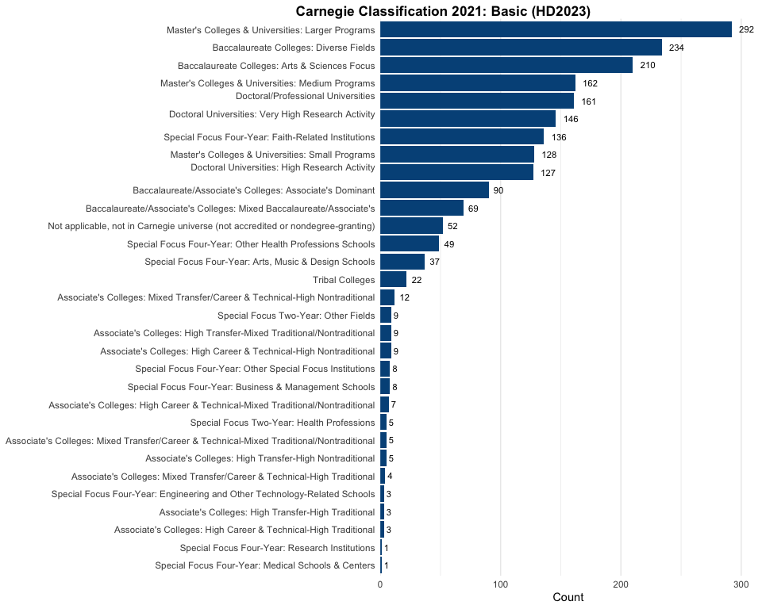

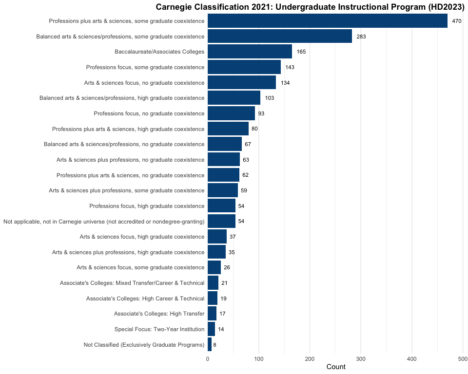

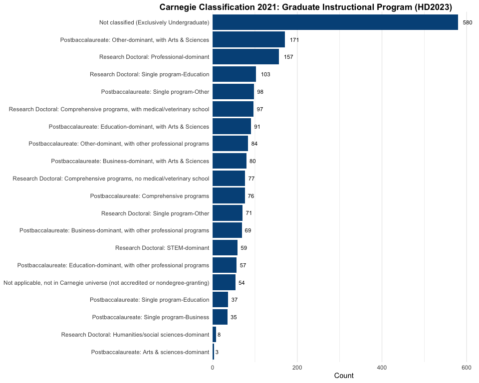

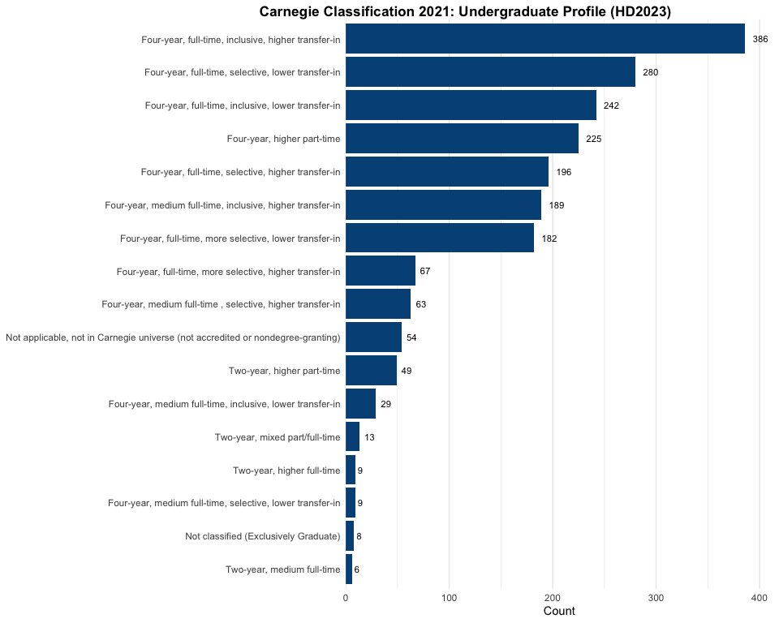

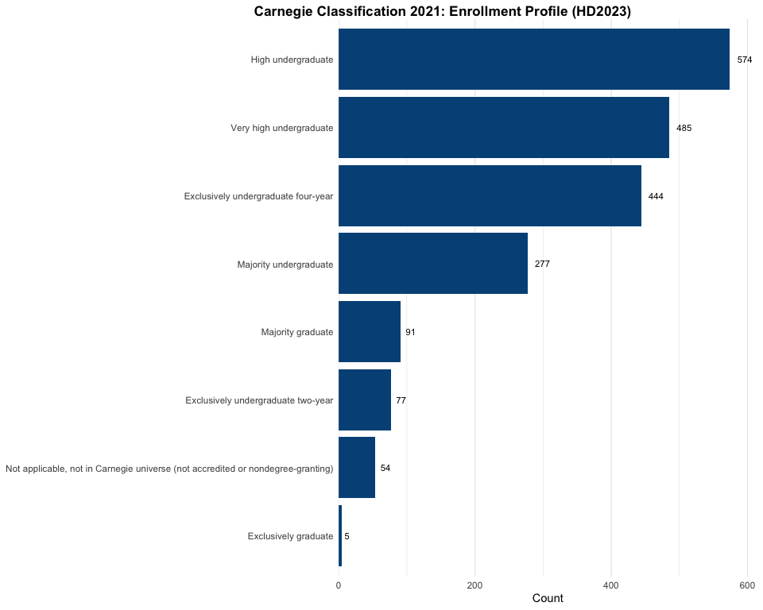

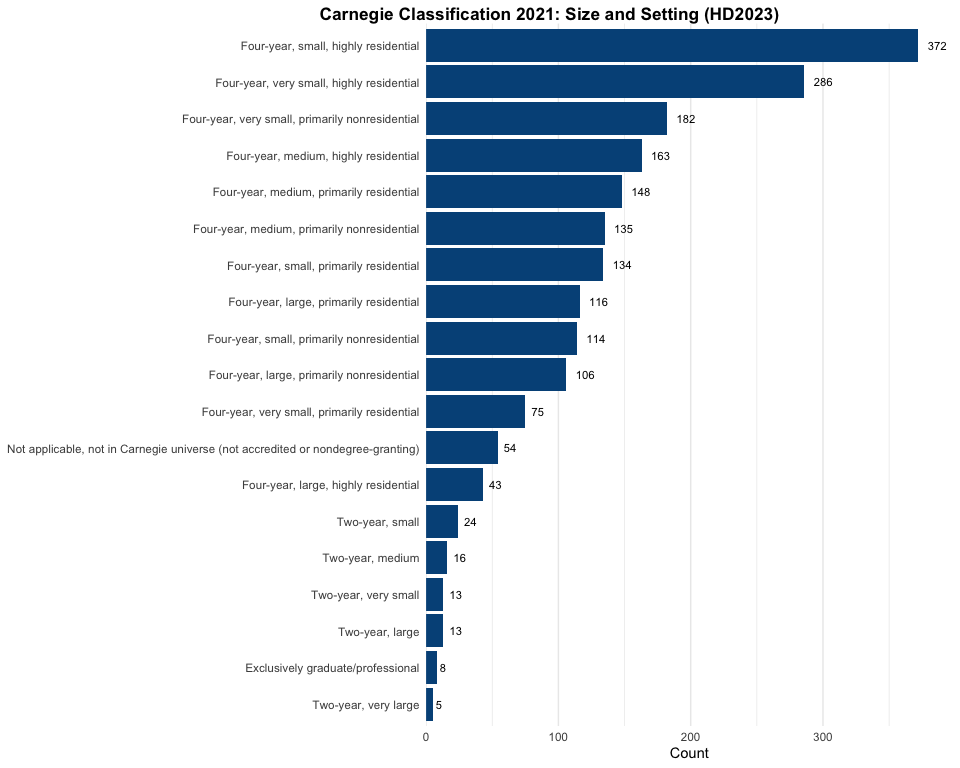

#### 1.3.2 Student Body

Let’s see what the variable names are here.

```
##
##                                                     Full-time undergraduate enrollment
##                                                                                  10035
##                                                     Part-time undergraduate enrollment
##                                                                                  10035
##                                             Percent of undergraduate enrollment  25-64
##                                                                                  10035
##          Percent of undergraduate enrollment that are American Indian or Alaska Native
##                                                                                  10035
##                                     Percent of undergraduate enrollment that are Asian
##                                                                                  10035
##    Percent of undergraduate enrollment that are Asian/Native Hawaiian/Pacific Islander
##                                                                                  10035
##                 Percent of undergraduate enrollment that are Black or African American
##                                                                                  10035
##                           Percent of undergraduate enrollment that are Hispanic/Latino
##                                                                                  10035
## Percent of undergraduate enrollment that are Native Hawaiian or Other Pacific Islander
##                                                                                  10035
##                         Percent of undergraduate enrollment that are Nonresident Alien
##                                                                                   6021
##                    Percent of undergraduate enrollment that are Race/ethnicity unknown
##                                                                                  10035
##                         Percent of undergraduate enrollment that are two or more races
##                                                                                  10035
##                          Percent of undergraduate enrollment that are U.S. Nonresident
##                                                                                   4014
##                                     Percent of undergraduate enrollment that are White
##                                                                                  10035
##                                     Percent of undergraduate enrollment that are women
##                                                                                  10035
##                          Percent of undergraduate students awarded Federal Pell grants
##                                                                                   2007
##                                  Percent of undergraduate students awarded Pell grants
##                                                                                   8028
##                                                               Undergraduate enrollment
##                                                                                  10035
```

The Pell and Non-resident variables are broken into two different variables due to different naming conventions. I’ll combine those.

```
##
##                                                     Full-time undergraduate enrollment
##                                                                                  10035
##                                                     Part-time undergraduate enrollment
##                                                                                  10035
##                                             Percent of undergraduate enrollment  25-64
##                                                                                  10035
##          Percent of undergraduate enrollment that are American Indian or Alaska Native
##                                                                                  10035
##                                     Percent of undergraduate enrollment that are Asian
##                                                                                  10035
##    Percent of undergraduate enrollment that are Asian/Native Hawaiian/Pacific Islander
##                                                                                  10035
##                 Percent of undergraduate enrollment that are Black or African American
##                                                                                  10035
##                           Percent of undergraduate enrollment that are Hispanic/Latino
##                                                                                  10035
## Percent of undergraduate enrollment that are Native Hawaiian or Other Pacific Islander
##                                                                                  10035
##                    Percent of undergraduate enrollment that are Race/ethnicity unknown
##                                                                                  10035
##                         Percent of undergraduate enrollment that are two or more races
##                                                                                  10035
##                          Percent of undergraduate enrollment that are U.S. Nonresident
##                                                                                  10035
##                                     Percent of undergraduate enrollment that are White
##                                                                                  10035
##                                     Percent of undergraduate enrollment that are women
##                                                                                  10035
##                          Percent of undergraduate students awarded Federal Pell grants
##                                                                                  10035
##                                                               Undergraduate enrollment
##                                                                                  10035
```

Great, everything is uniform now. I’ll pivot the dataset to better create a descriptive table. Note that the schools and/or years with 0 enrollment should be removed from the dataset when we do the analysis.

Summary Statistics by Year

| clean label | mean 2019 | mean 2020 | mean 2021 | mean 2022 | mean 2023 | median 2019 | median 2020 | median 2021 | median 2022 | median 2023 | n | min | max |
| --- | --- | --- | --- | --- | --- | --- | --- | --- | --- | --- | --- | --- | --- |
| Full-time undergraduate enrollment | 3933.6 | 3850.6 | 3754.9 | 3714.8 | 3785.5 | 1648 | 1572 | 1514 | 1450 | 1471 | 9939 | 0 | 135822 |
| Part-time undergraduate enrollment | 1405.8 | 1410.3 | 1394.2 | 1375.1 | 1387.0 | 255 | 264 | 250 | 242 | 240 | 9939 | 0 | 110546 |
| Percent of undergraduate enrollment 25-64 | 19.4 | 18.5 | 19.5 | 17.3 | 18.6 | 13 | 13 | 13 | 11 | 11 | 8518 | 0 | 100 |
| Percent of undergraduate enrollment that are American Indian or Alaska Native | 1.4 | 1.5 | 1.5 | 1.4 | 1.5 | 0 | 0 | 0 | 0 | 0 | 9925 | 0 | 100 |
| Percent of undergraduate enrollment that are Asian | 4.3 | 4.5 | 4.6 | 4.6 | 4.6 | 2 | 2 | 2 | 2 | 2 | 9925 | 0 | 97 |
| Percent of undergraduate enrollment that are Asian/Native Hawaiian/Pacific Islander | 4.6 | 4.7 | 4.8 | 4.8 | 4.9 | 2 | 3 | 3 | 3 | 3 | 9905 | 0 | 97 |
| Percent of undergraduate enrollment that are Black or African American | 13.0 | 13.2 | 13.1 | 13.1 | 13.3 | 7 | 7 | 7 | 7 | 7 | 9925 | 0 | 100 |
| Percent of undergraduate enrollment that are Hispanic/Latino | 12.4 | 13.1 | 13.4 | 13.8 | 14.3 | 8 | 9 | 9 | 9 | 10 | 9925 | 0 | 100 |
| Percent of undergraduate enrollment that are Native Hawaiian or Other Pacific Islander | 0.2 | 0.2 | 0.2 | 0.2 | 0.2 | 0 | 0 | 0 | 0 | 0 | 9925 | 0 | 24 |
| Percent of undergraduate enrollment that are Race/ethnicity unknown | 4.4 | 4.5 | 4.6 | 4.6 | 4.6 | 3 | 3 | 3 | 3 | 2 | 9925 | 0 | 98 |
| Percent of undergraduate enrollment that are U.S. Nonresident | 4.3 | 3.8 | 3.9 | 4.2 | 4.2 | 2 | 2 | 2 | 2 | 2 | 9925 | 0 | 100 |
| Percent of undergraduate enrollment that are White | 56.2 | 55.5 | 54.8 | 54.0 | 53.2 | 61 | 60 | 59 | 58 | 57 | 9925 | 0 | 100 |
| Percent of undergraduate enrollment that are two or more races | 3.5 | 3.7 | 3.7 | 3.8 | 4.0 | 3 | 3 | 4 | 4 | 4 | 9925 | 0 | 37 |
| Percent of undergraduate enrollment that are women | 54.9 | 55.5 | 55.3 | 54.9 | 54.7 | 57 | 58 | 57 | 57 | 57 | 9925 | 0 | 100 |
| Percent of undergraduate students awarded Federal Pell grants | 37.1 | 36.4 | 35.2 | 34.7 | 34.2 | 35 | 34 | 33 | 33 | 32 | 9900 | 0 | 100 |
| Undergraduate enrollment | 5339.5 | 5260.9 | 5149.2 | 5089.9 | 5172.4 | 2073 | 2020 | 1957 | 1873 | 1910 | 9939 | 0 | 159653 |

### 1.4 Geographic and non-IPEDS Data (Kurt)

Calculate descriptive statistics for Region, Locale, HS grads by state, and Percent Bachelors holders by state

```
## $BEA_Region
## # A tibble: 9 × 3
##   Values                                                     Val_N       Val_Pct
##   <chr>                                                      <table[1d]> <table>
## 1 Southeast (AL, AR, FL, GA, KY, LA, MS, NC, SC, TN, VA, WV) 475         23.7
## 2 Mid East (DE, DC, MD, NJ, NY, PA)                          403         20.1
## 3 Great Lakes (IL, IN, MI, OH, WI)                           306         15.2
## 4 Far West (AK, CA, HI, NV, OR, WA)                          236         11.8
## 5 Plains (IA, KS, MN, MO, NE, ND, SD)                        206         10.3
## 6 Southwest (AZ, NM, OK, TX)                                 161          8.0
## 7 New England (CT, ME, MA, NH, RI, VT)                       151          7.5
## 8 Rocky Mountains (CO, ID, MT, UT, WY)                        68          3.4
## 9 U.S. Service schools                                         1          0.0
##
## $Locale
## # A tibble: 12 × 3
##    Values          Val_N       Val_Pct
##    <chr>           <table[1d]> <table[1d]>
##  1 City: Large     451         22.5
##  2 Suburb: Large   391         19.5
##  3 City: Small     289         14.4
##  4 City: Midsize   239         11.9
##  5 Town: Distant   187          9.3
##  6 Town: Remote    113          5.6
##  7 Rural: Fringe    84          4.2
##  8 Rural: Distant   65          3.2
##  9 Suburb: Midsize  57          2.8
## 10 Town: Fringe     56          2.8
## 11 Rural: Remote    42          2.1
## 12 Suburb: Small    33          1.6
##
## $HS_Grad_2017
## $HS_Grad_2017[[1]]
## [1]   4495.0  56428.5 109762.0 203147.0 470869.0
##
## $HS_Grad_2017[[2]]
## [1] 137781.3 120754.1
##
##
## $ACS_Pct_Bachelors
## $ACS_Pct_Bachelors[[1]]
## [1] 21.3 29.5 31.8 36.7 60.4
##
## $ACS_Pct_Bachelors[[2]]
## [1] 32.765222  5.267823
```

## 2 Exploratory Questions

### 2.1 Overall Trends

Guiding Questions:

- What is the percent of [institutions] that have seen an increase in undergraduate enrollment [in recent history]? What is the percent of [institutions] that have seen a decrease in undergraduate enrollment [in recent history]?
- What percent of [institutions] have seen an increase in undergraduate enrollment [in recent history] of [scale, e.g., 10% or more]? What is the percent of [institutions] that have seen a decrease in undergraduate enrollment [in recent history] of [scale, e.g., 10% or more]?

### 2.2 Changing Enrollment

Guiding Questions:

- Is change in undergraduate enrollment [in recent history] correlated with change in application volume (number of applicants)? At what scale? [Same year]
- Is change in undergraduate enrollment [in recent history] correlated with change in yield rate (% of admitted students who enroll at the institution)? At what scale?
- Is change in undergraduate enrollment [in recent history] correlated with change in “attractor score” (number of applicants * yield rate)? At what scale?
- Is change in undergraduate enrollment [in recent history] correlated with change in new student enrollment (first-time, first-year and transfer students, together and/or separately)?

### 2.3 Student Composition

Which student populations are increasing/decreasing in enrollment? - Enrollment by race/ethnicity - Percent Pell - Adult age (25-64) enrollment

### 2.4 Intersection between Enrollment and Graduation

TBD.